# Assembling an R Visualization Presentation

Dhruv Kotecha

2022-02-24

# About The Data

I am going to use the csv file from “Amazon Top 50 Bestselling Books 2009 - 2019”. This data set contains 7-Columns. The column names are: Author: The author of the book.

Name of the book.

User rating: Amazon user rating.

Reviews: Number of written reviews on amazon.

Price: The price of the book.

Year: The Year(s) it ranked on the bestseller.

Genre: Whether fiction or non-fiction.

For this case I am choosing R programming, because it allow me work with big amounts of data, cleaning data and create visualizations with little code. Also, I will use R Markdown to reproduce, share my code, and document all the work that I am going to do.

Data set Link- https://www.kaggle.com/sootersaalu/amazon-top-50-bestselling-books-2009-2019

# Problem Statement

The data set containing the Amazon Bestselling Books allows us to analyze how, over time, which genres of books did well and which authors sold the most books. We also provide user ratings and reviews for each book, which can help customers narrow down their choices. By doing this visualization, we have a clear representation of the data set as well as an easy comprehension of which author and genre fared best.

# Summary

```
##   user_rating       reviews          price
##  Min.   :3.300   Min.   :   37   Min.   :  0.0
##  1st Qu.:4.500   1st Qu.: 4058   1st Qu.:  7.0
##  Median :4.700   Median : 8580   Median : 11.0
##  Mean   :4.618   Mean   :11953   Mean   : 13.1
##  3rd Qu.:4.800   3rd Qu.:17253   3rd Qu.: 16.0
##  Max.   :4.900   Max.   :87841   Max.   :105.0
```

# Top selling books by genre from 2009-2019

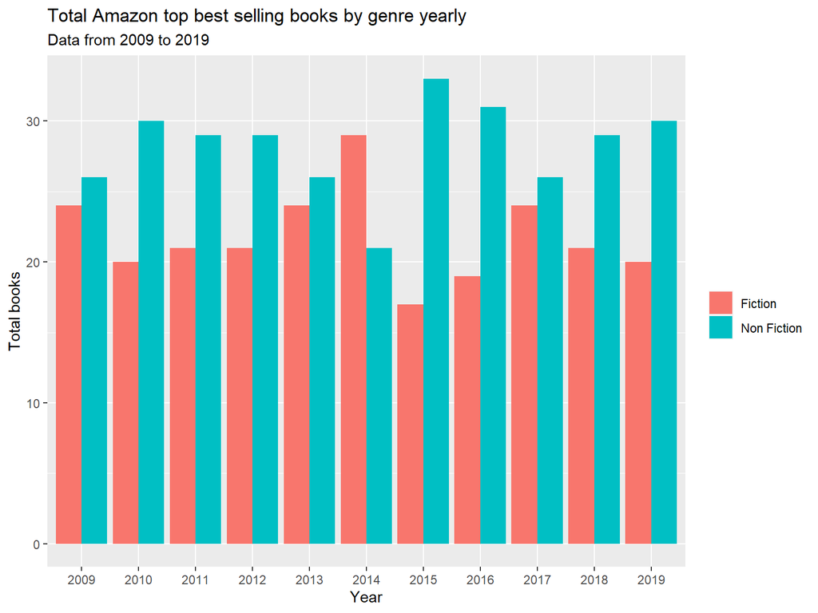